# 04

```python
import numpy as np
import seaborn as sns
import matplotlib.pyplot as plt
from scipy.stats import norm
```

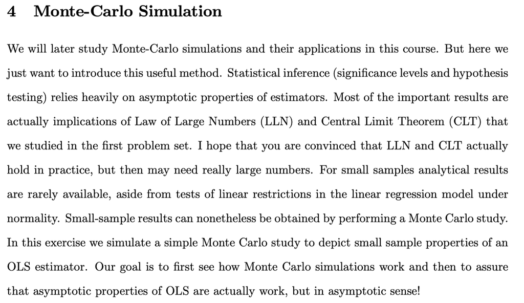

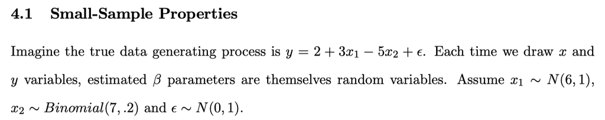

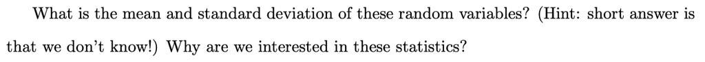

Under certain assumptions, the OLS estimators are unbiased, which means that their expected value equals the true value of the parameters they estimate. Thus, in $y = \beta_{0} + \beta_{1} \times x1 + \beta_{2} \times x2 + \epsilon$ we have $E[\hat{\beta}] = E[(\hat{\beta_{0}}, \hat{\beta_{1}}, \hat{\beta_{2}})]= (\beta_{0}, \beta_{1}, \beta_{2}) = (2, 3, -5)$.

The variance-covariance matrix of $\hat{\beta}$ is: $\text{Var}(\hat{\beta}) = \sigma^2 (X'X)^{-1}$, where $\sigma^2$ is the variance of the error term in the regression model, and $X$ is the matrix of independent variables (including a column of ones for the intercept), with each column being one of the variables in the regression model. Each diagonal element of $\text{Var}(\hat{\beta})$ gives the variance of the corresponding estimator.

It is important to note that these means and variances are calculated conditional on $X$, the matrix of independent variables. The general calculations of means and variances depend on the distribution of $X$, highlighting that while the estimators are unbiased and their variances are well-defined within the context of given $X$, the overall behavior and characteristics of these estimators can vary depending on the underlying distribution of $X$.

In Ordinary Least Squares (OLS) regression, we are interested in the mean and variance of the estimated coefficients because the mean provides an estimate of the average effect of each independent variable on the dependent variable, assuming other variables are held constant. The variance helps assess the precision of these estimates, with lower variance indicating more reliable estimates. Understanding both helps in making statistical inferences about the relationship between variables, such as testing hypotheses or constructing confidence intervals.

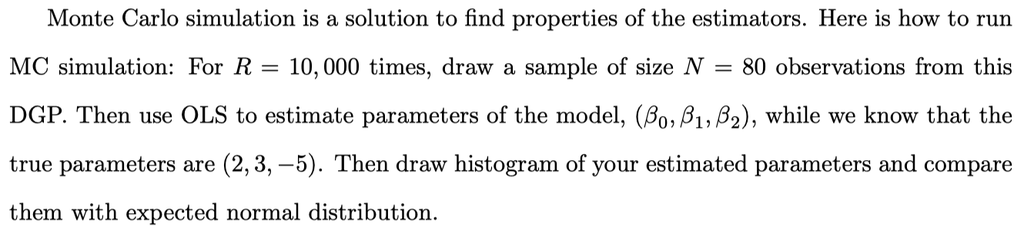

```python
def estimate_params(R, N):
    x1 = np.random.normal(6, 1, size=(N, R))
    x2 = np.random.binomial(7, 0.2, size=(N, R))
    error = np.random.normal(0, 1, size=(N, R))
    y = 2 + 3 * x1 - 5 * x2 + error

    X = np.stack([np.ones((N, R)), x1, x2], axis=1)  # Shape (N, 3, R)
    X_reshaped = X.transpose(2, 0, 1).reshape(R, N, 3)  # Shape (R, N, 3)

    y_reshaped = y.T  # shape (R, N)
    X_p_X_inv = np.linalg.inv(X_reshaped.transpose(0, 2, 1) @ X_reshaped)
    betas = X_p_X_inv @ (X_reshaped.transpose(0, 2, 1) @ y_reshaped[:, :, np.newaxis]) # shape (R, 3, 1)
    return betas, X_p_X_inv
```

```python
betas, X_prime_X_inv =  estimate_params(R = 10_000, N = 80)
beta0 = betas[:, 0, 0]
beta1 = betas[:, 1, 0]
beta2 = betas[:, 2, 0]
b0_var = X_prime_X_inv.mean(axis=0).diagonal()[0]
b1_var = X_prime_X_inv.mean(axis=0).diagonal()[1]
b2_var = X_prime_X_inv.mean(axis=0).diagonal()[2]
```

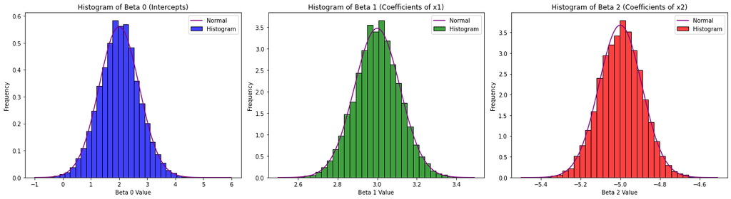

```python
fig, axes = plt.subplots(1, 3, figsize=(18, 5))

# Plot histograms for each beta
sns.histplot(beta0, bins=30, color="blue", edgecolor="k",stat="density",label='Histogram', ax=axes[0])
sns.lineplot(x=np.arange(-1, 6, 0.01), y=norm.pdf(np.arange(-1, 6, 0.01), 2,b0_var**0.5),color="purple",label='Normal', ax=axes[0])
axes[0].set_title('Histogram of Beta 0 (Intercepts)')
axes[0].set_xlabel('Beta 0 Value')
axes[0].set_ylabel('Frequency')
axes[0].legend()

sns.histplot(beta1, bins=30, color="green", edgecolor="k",stat="density",label='Histogram', ax=axes[1])
sns.lineplot(x=np.arange(2.5, 3.5, 0.01), y=norm.pdf(np.arange(2.5, 3.5, 0.01), 3,b1_var**0.5),color="purple",label='Normal', ax=axes[1])
axes[1].set_title('Histogram of Beta 1 (Coefficients of x1)')
axes[1].set_xlabel('Beta 1 Value')
axes[1].set_ylabel('Frequency')

sns.histplot(beta2, bins=30, color="red", edgecolor="k",stat="density",label='Histogram', ax=axes[2])
sns.lineplot(x=np.arange(-5.5, -4.5, 0.01), y=norm.pdf(np.arange(-5.5, -4.5, 0.01), -5,b2_var**0.5),color="purple",label='Normal', ax=axes[2])
axes[2].set_title('Histogram of Beta 2 (Coefficients of x2)')
axes[2].set_xlabel('Beta 2 Value')
axes[2].set_ylabel('Frequency')

plt.tight_layout()
plt.show()
```

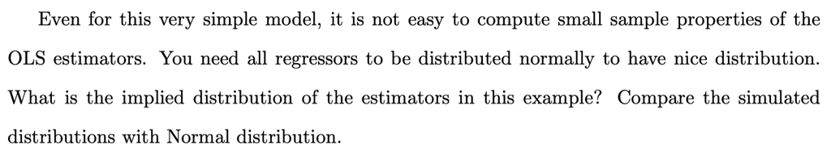

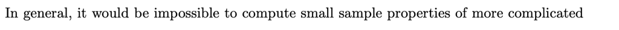

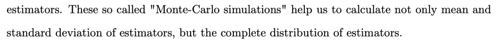

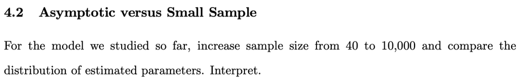

```python
betas_prime, X_prime_X_inverse_prime =  estimate_params(R = 10_000, N = 10_000)
beta0_prime = betas_prime[:, 0, 0]
beta1_prime = betas_prime[:, 1, 0]
beta2_prime = betas_prime[:, 2, 0]
b0_var_prime = X_prime_X_inverse_prime.mean(axis=0).diagonal()[0]
b1_var_prime = X_prime_X_inverse_prime.mean(axis=0).diagonal()[1]
b2_var_prime = X_prime_X_inverse_prime.mean(axis=0).diagonal()[2]
```

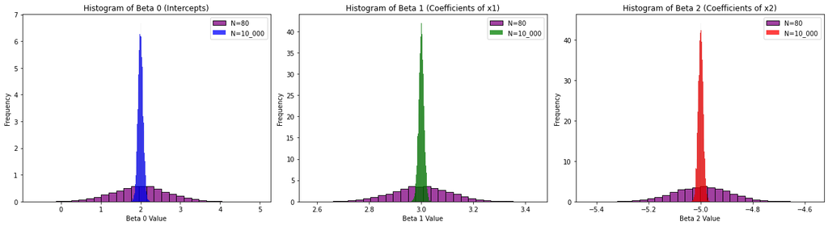

```python
fig, axes = plt.subplots(1, 3, figsize=(18, 5))

# Plot histograms for each beta
sns.histplot(beta0, bins=30, color="purple", edgecolor="k",stat="density",label='N=80', ax=axes[0])
sns.histplot(beta0_prime, bins=50, color="blue", edgecolor="k",stat="density",label='N=10_000', ax=axes[0])
axes[0].set_title('Histogram of Beta 0 (Intercepts)')
axes[0].set_xlabel('Beta 0 Value')
axes[0].set_ylabel('Frequency')
axes[0].legend()

sns.histplot(beta1, bins=30, color="purple", edgecolor="k",stat="density",label='N=80', ax=axes[1])
sns.histplot(beta1_prime, bins=50, color="green", edgecolor="k",stat="density",label='N=10_000', ax=axes[1])
axes[1].set_title('Histogram of Beta 1 (Coefficients of x1)')
axes[1].set_xlabel('Beta 1 Value')
axes[1].set_ylabel('Frequency')
axes[1].legend()

sns.histplot(beta2, bins=30, color="purple", edgecolor="k",stat="density",label='N=80', ax=axes[2])
sns.histplot(beta2_prime, bins=50, color="red", edgecolor="k",stat="density",label='N=10_000', ax=axes[2])
axes[2].set_title('Histogram of Beta 2 (Coefficients of x2)')
axes[2].set_xlabel('Beta 2 Value')
axes[2].set_ylabel('Frequency')
axes[2].legend()

plt.tight_layout()
plt.show()
```

With the increase in the number of samples from 80 to 10,000, we observe that the precision of the estimators has increased and their variance is smaller.

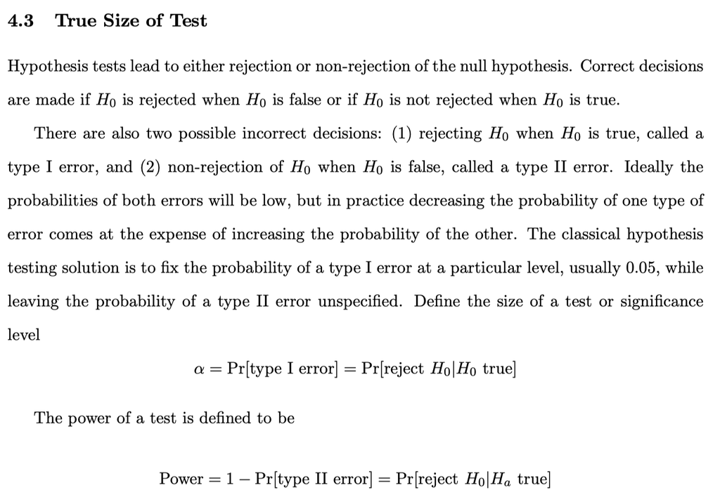

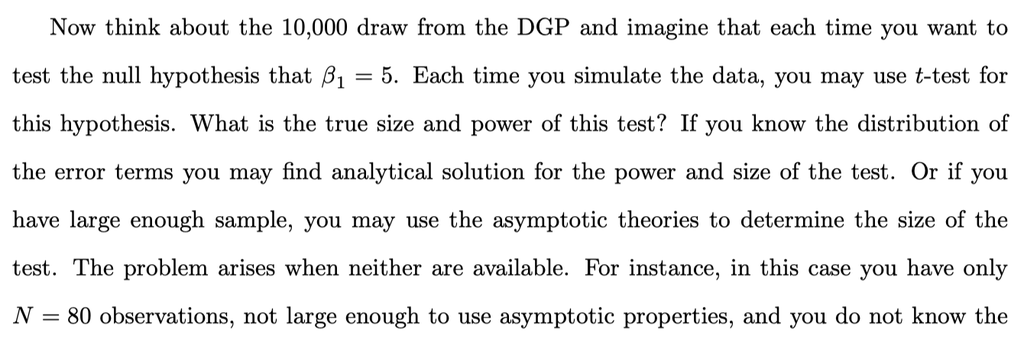

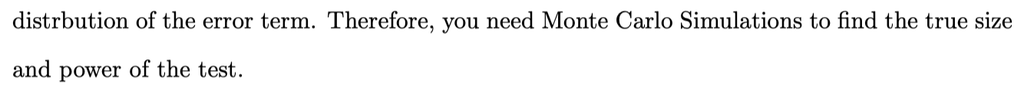

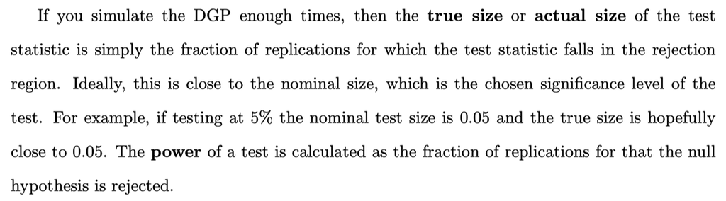

```python
true_beta1 = 3
alpha = 0.05
R = 10000
b1_sd_per_iteration = (X_prime_X_inv[:,1,1])**0.5
true_size = np.sum(np.absolute((beta1 - true_beta1)/ b1_sd_per_iteration)>norm.ppf(1-alpha/2))/R
print('True size is:    ',true_size)
```

```
True size is:     0.0513
```

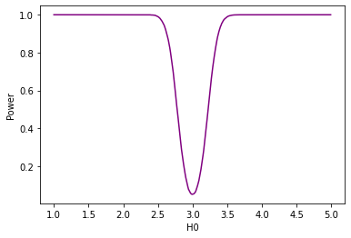

```python
H0 = x = np.arange(1, 5, 0.01)
alpha = 0.05
power = [np.sum(np.absolute((beta1 - i)/ b1_sd_per_iteration)>norm.ppf(1-alpha/2))/R for i in H0]
sns.lineplot(x=H0, y=power,color="purple")
plt.xlabel('H0')
plt.ylabel('Power')
plt.show()
```

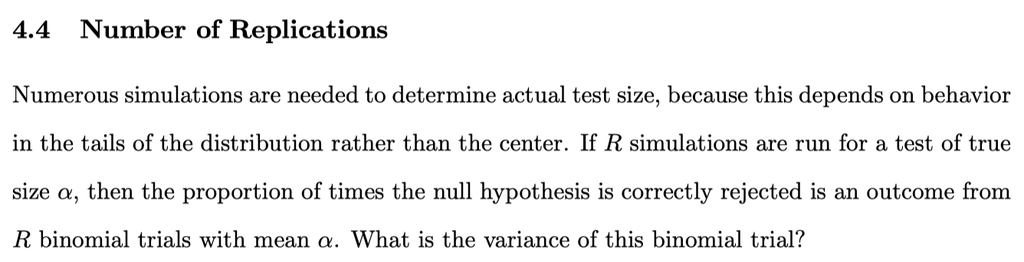

$R * \alpha * (1- \alpha)$

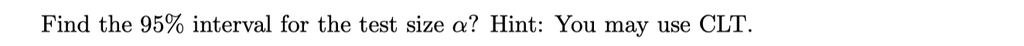

$\frac{(\bar{\alpha} - \alpha)}{sd(\bar{\alpha})/\sqrt{n}} \sim N(0,1)$

```python
b1_prime_sd_per_iteration = (X_prime_X_inverse_prime[:,1,1])**0.5
true_size_list = np.absolute((beta1_prime - true_beta1)/ b1_prime_sd_per_iteration)>norm.ppf(1-alpha/2)
confidence_interval = [np.mean(true_size_list)-np.var(true_size_list)**0.5 * norm.ppf(1-alpha/2)/(len(true_size_list))**0.5,
                       np.mean(true_size_list)+np.var(true_size_list)**0.5 * norm.ppf(1-alpha/2)/(len(true_size_list))**0.5]
confidence_interval
```

```
[0.04928175643174092, 0.05811824356825908]
```

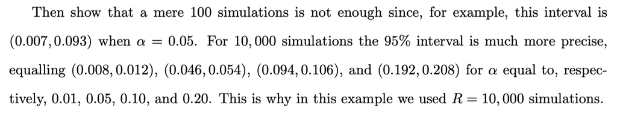

```python
for alpha in [0.01,0.05, 0.1, 0.2]:
    true_size_list = np.absolute((beta1_prime - true_beta1)/ b1_prime_sd_per_iteration)>norm.ppf(1-alpha/2)
    confidence_interval = [np.mean(true_size_list)-np.var(true_size_list)**0.5 * norm.ppf(1-alpha/2)/(len(true_size_list))**0.5,
                       np.mean(true_size_list)+np.var(true_size_list)**0.5 * norm.ppf(1-alpha/2)/(len(true_size_list))**0.5]
    print("alpha = ", alpha ,",    confidence interval: " , confidence_interval)
```

```
alpha =  0.01 ,    confidence interval:  [0.008665488158932694, 0.014134511841067307]
alpha =  0.05 ,    confidence interval:  [0.04928175643174092, 0.05811824356825908]
alpha =  0.1 ,    confidence interval:  [0.09721755509295409, 0.10718244490704591]
alpha =  0.2 ,    confidence interval:  [0.19626038637756843, 0.20653961362243156]
```

```python
betas_tild, X_prime_X_inverse_tild =  estimate_params(R = 100, N = 10_000)
beta0_tild = betas_tild[:, 0, 0]
beta1_tild = betas_tild[:, 1, 0]
beta2_tild = betas_tild[:, 2, 0]
b1_tild_sd_per_iteration = (X_prime_X_inverse_tild[:,1,1])**0.5
true_size_list = np.absolute((beta1_tild - true_beta1)/ b1_tild_sd_per_iteration)>norm.ppf(1-0.05/2)
confidence_interval = [np.mean(true_size_list)-np.var(true_size_list)**0.5 * norm.ppf(1-0.05/2)/(len(true_size_list))**0.5,
                    np.mean(true_size_list)+np.var(true_size_list)**0.5 * norm.ppf(1-0.05/2)/(len(true_size_list))**0.5]
print("alpha = ", 0.05 ,",    confidence interval: " , confidence_interval)
```

```
alpha =  0.05 ,    confidence interval:  [0.007283575292052952, 0.09271642470794705]
```

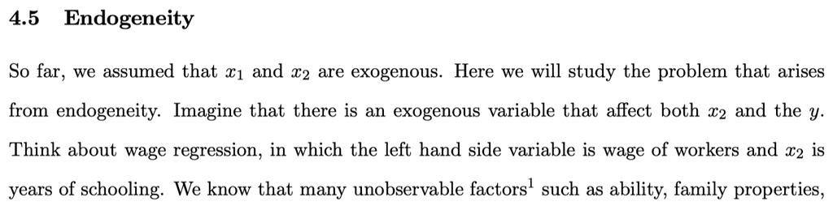

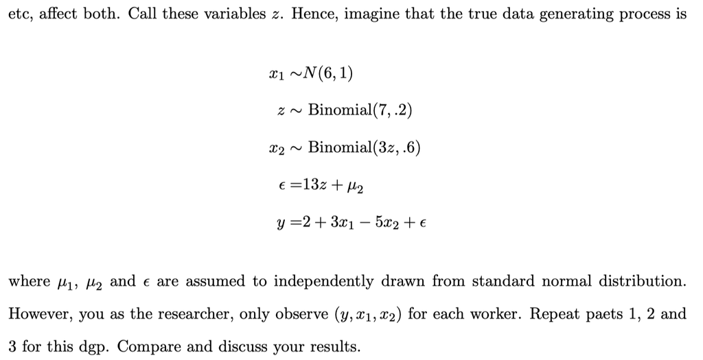

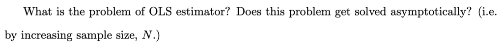

```python
def estimate_params_2(R, N):
    x1 = np.random.normal(6, 1, size=(N, R))
    z = np.random.binomial(7, 0.2, size=(N, R))
    x2 = np.random.binomial(3*z, 0.6, size=(N, R))
    error = np.random.normal(0, 1, size=(N, R)) + 13 * z
    y = 2 + 3 * x1 - 5 * x2 + error

    X = np.stack([np.ones((N, R)), x1, x2], axis=1)  # Shape (N, 3, R)
    X_reshaped = X.transpose(2, 0, 1).reshape(R, N, 3)  # Shape (R, N, 3)

    y_reshaped = y.T  # shape (R, N)
    X_p_X_inv = np.linalg.inv(X_reshaped.transpose(0, 2, 1) @ X_reshaped)
    betas = X_p_X_inv @ (X_reshaped.transpose(0, 2, 1) @ y_reshaped[:, :, np.newaxis]) # shape (R, 3, 1)
    betas_reshaped = betas.squeeze(axis=-1)
    residuals = y_reshaped - np.matmul(X_reshaped, betas_reshaped[:, :, np.newaxis]).squeeze(axis=-1)
    sigma_squared = np.mean(residuals ** 2)
    return betas, X_p_X_inv, sigma_squared
```

```python
betas_part5, X_prime_X_inv_part5, sigma_squared =  estimate_params_2(R = 10_000, N = 80)
beta0_part5 = betas_part5[:, 0, 0]
beta1_part5 = betas_part5[:, 1, 0]
beta2_part5 = betas_part5[:, 2, 0]
b0_var_part5 = X_prime_X_inv_part5.mean(axis=0).diagonal()[0] * sigma_squared
b1_var_part5 = X_prime_X_inv_part5.mean(axis=0).diagonal()[1] * sigma_squared
b2_var_part5 = X_prime_X_inv_part5.mean(axis=0).diagonal()[2] * sigma_squared
```

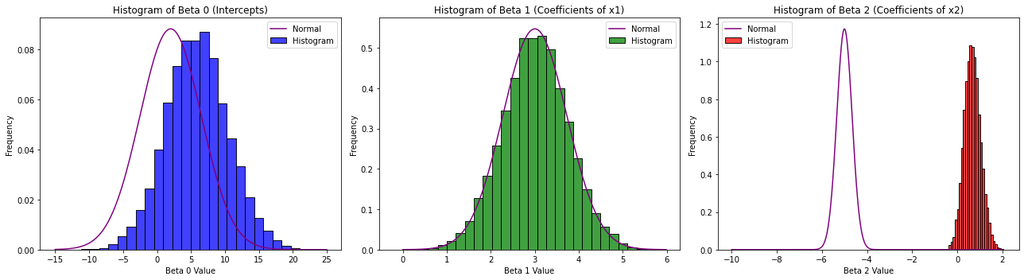

```python
fig, axes = plt.subplots(1, 3, figsize=(18, 5))

# Plot histograms for each beta
sns.histplot(beta0_part5, bins=30, color="blue", edgecolor="k",stat="density",label='Histogram', ax=axes[0])
sns.lineplot(x=np.arange(-15, 25, 0.01), y=norm.pdf(np.arange(-15, 25, 0.01), 2,b0_var_part5**0.5),color="purple",label='Normal', ax=axes[0])
axes[0].set_title('Histogram of Beta 0 (Intercepts)')
axes[0].set_xlabel('Beta 0 Value')
axes[0].set_ylabel('Frequency')
axes[0].legend()

sns.histplot(beta1_part5, bins=30, color="green", edgecolor="k",stat="density",label='Histogram', ax=axes[1])
sns.lineplot(x=np.arange(0, 6, 0.01), y=norm.pdf(np.arange(0, 6, 0.01), 3,b1_var_part5**0.5),color="purple",label='Normal', ax=axes[1])
axes[1].set_title('Histogram of Beta 1 (Coefficients of x1)')
axes[1].set_xlabel('Beta 1 Value')
axes[1].set_ylabel('Frequency')

sns.histplot(beta2_part5, bins=30, color="red", edgecolor="k",stat="density",label='Histogram', ax=axes[2])
sns.lineplot(x=np.arange(-10, 2, 0.01), y=norm.pdf(np.arange(-10, 2, 0.01), -5,b2_var_part5**0.5),color="purple",label='Normal', ax=axes[2])
axes[2].set_title('Histogram of Beta 2 (Coefficients of x2)')
axes[2].set_xlabel('Beta 2 Value')
axes[2].set_ylabel('Frequency')

plt.tight_layout()
plt.show()
```

Because of Endogeneity, there is bias in estimated parameters $\hat{\beta_{0}}$ and $\hat{\beta_{2}}$.

```python
betas_prime_part5, X_prime_X_inverse_prime_part5,sigma_squared_part5 =  estimate_params_2(R = 10_000, N = 10_000)
beta0_prime_part5 = betas_prime_part5[:, 0, 0]
beta1_prime_part5 = betas_prime_part5[:, 1, 0]
beta2_prime_part5 = betas_prime_part5[:, 2, 0]
b0_var_prime_part5 = X_prime_X_inverse_prime_part5.mean(axis=0).diagonal()[0] *sigma_squared_part5
b1_var_prime_part5 = X_prime_X_inverse_prime_part5.mean(axis=0).diagonal()[1] *sigma_squared_part5
b2_var_prime_part5 = X_prime_X_inverse_prime_part5.mean(axis=0).diagonal()[2] *sigma_squared_part5
```

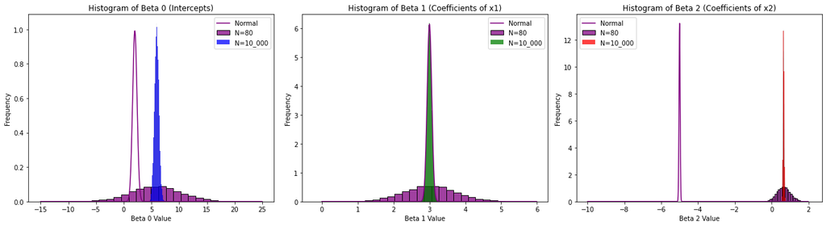

```python
fig, axes = plt.subplots(1, 3, figsize=(18, 5))

# Plot histograms for each beta
sns.histplot(beta0_part5, bins=30, color="purple", edgecolor="k",stat="density",label='N=80', ax=axes[0])
sns.histplot(beta0_prime_part5, bins=50, color="blue", edgecolor="k",stat="density",label='N=10_000', ax=axes[0])
sns.lineplot(x=np.arange(-15, 25, 0.01), y=norm.pdf(np.arange(-15, 25, 0.01), 2,b0_var_prime_part5**0.5),color="purple",label='Normal', ax=axes[0])
axes[0].set_title('Histogram of Beta 0 (Intercepts)')
axes[0].set_xlabel('Beta 0 Value')
axes[0].set_ylabel('Frequency')
axes[0].legend()

sns.histplot(beta1_part5, bins=30, color="purple", edgecolor="k",stat="density",label='N=80', ax=axes[1])
sns.histplot(beta1_prime_part5, bins=50, color="green", edgecolor="k",stat="density",label='N=10_000', ax=axes[1])
sns.lineplot(x=np.arange(0, 6, 0.01), y=norm.pdf(np.arange(0, 6, 0.01), 3,b1_var_prime_part5**0.5),color="purple",label='Normal', ax=axes[1])
axes[1].set_title('Histogram of Beta 1 (Coefficients of x1)')
axes[1].set_xlabel('Beta 1 Value')
axes[1].set_ylabel('Frequency')
axes[1].legend()

sns.histplot(beta2_part5, bins=30, color="purple", edgecolor="k",stat="density",label='N=80', ax=axes[2])
sns.histplot(beta2_prime_part5, bins=50, color="red", edgecolor="k",stat="density",label='N=10_000', ax=axes[2])
sns.lineplot(x=np.arange(-10, 2, 0.01), y=norm.pdf(np.arange(-10, 2, 0.01), -5,b2_var_prime_part5**0.5),color="purple",label='Normal', ax=axes[2])
axes[2].set_title('Histogram of Beta 2 (Coefficients of x2)')
axes[2].set_xlabel('Beta 2 Value')
axes[2].set_ylabel('Frequency')
axes[2].legend()

plt.tight_layout()
plt.show()
```

As you see the problem does not solve by increasing the sample size.

```python
true_beta1_part5 = 3
alpha = 0.05
R = 10000
b1_sd_per_iteration_part5 = (X_prime_X_inv_part5[:,1,1]*sigma_squared)**0.5
true_size_part5 = np.sum(np.absolute((beta1_part5 - true_beta1_part5)/ b1_sd_per_iteration_part5)>norm.ppf(1-alpha/2))/R
print('True size is:    ',true_size_part5)
```

```
True size is:     0.0572
```

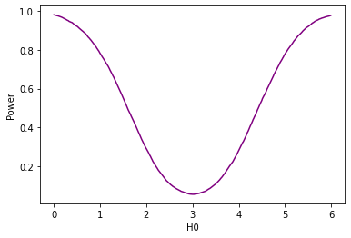

```python
H0 = x = np.arange(0, 6, 0.01)
alpha = 0.05
power = [np.sum(np.absolute((beta1_part5 - i)/ b1_sd_per_iteration_part5)>norm.ppf(1-alpha/2))/R for i in H0]
sns.lineplot(x=H0, y=power,color="purple")
plt.xlabel('H0')
plt.ylabel('Power')
plt.show()
```